# **Basic lecture: Gaussian process 기반 single-fidelity 모델 (Kriging) 실습 Ⅱ**

By Mingyu Lee, Hwisang Jo, and Ikjin Lee

http://idol.kaist.ac.kr/

mglee91@kaist.ac.kr

IDOL Lab at KAIST

### **< Source papers >**

- Le Gratiet, L. (2013). Multi-fidelity Gaussian process regression for computer experiments (Doctoral dissertation, Université Paris-Diderot-Paris VII).
- **Lee, M.**, Jung, Y., Choi, J., & Lee, I. (2022). A reanalysis-based multi-fidelity (RBMF) surrogate framework for efficient structural optimization. Computers & Structures, 273, 106895.

Original source codes from https://github.com/SMTorg/SMT

Modified version by Mingyu Lee

### **< Contents >**

1) One-dimensional Kriging example

**2) Two-dimensional Kriging example**

3) One-dimensional Co-Kriging example

4) Bayesian optimization

## **▣ 체계적으로 대리모델의 성능을 증가시키는 방법**

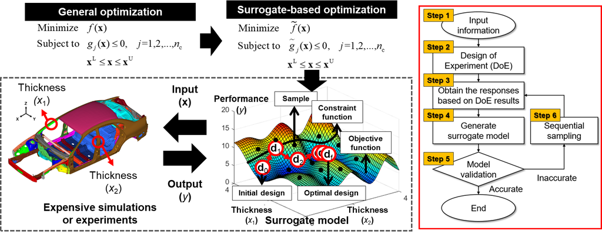

**1) 실험계획법 수행 (Step2)**

- 디자인 영역에서 다른 샘플과 겹치지 않으면서 (orthogonality) 고르게 (space-filling) 데이터를 확보

**2) 보유한 데이터 개수와 설계 변수 개수에 따른 대리 모델 선택 및 생성 (Step 4)**

- 인공신경망 기반 방법 vs 가우시안 프로세스 기반 방법 (e.g., Kriging, Co-Kriging)

**3) 기존의 샘플을 기반으로 유망한 영역에 샘플을 추가하여 대리 모델 업데이트 (Step 6)**

- Sequential sampling process (e.g., Bayesian optimization)

## **▣ 실습: Two-dimensional Kriging example**

### ※ **예제 문제**

- 설계 변수 개수: 2개
- 설계 공간: -2<x<sub>1</sub><2, -2<x<sub>2</sub><2
- 예제 함수: Rosenbrock function
- 데이터 개수: 20개
- Kriging으로 대리모델링을 수행

```python
from __future__ import print_function, division
import numpy as np
from scipy import linalg
from smt.utils import compute_rms_error

from smt.problems import Sphere, NdimRobotArm, Rosenbrock
from smt.sampling_methods import LHS
from smt.surrogate_models import LS, QP, KPLS, KRG, KPLSK, GEKPLS, MGP
try:
    from smt.surrogate_models import IDW, RBF, RMTC, RMTB
    compiled_available = True
except:
    compiled_available = False

try:
    import matplotlib.pyplot as plt
    plot_status = True
except:
    plot_status = False

import scipy.interpolate

from mpl_toolkits.mplot3d import Axes3D
import matplotlib.pyplot as plt
from matplotlib import cm
```

## **Step 1: 인풋 정보 (or 전처리 과정)**

```python
ndim = 2 # 설계 변수 개수 (차원)
ndoe = 20 # 초기 데이터 개수

fun = Rosenbrock(ndim = ndim) # Black-box 모델 정의 (e.g., 함수, 시뮬레이션 모델)
```

## **Step2: 실험계획법 (DOE)**

```python
# 실험계획법 수행
# 디자인 영역에서 다른 샘플과 겹치지 않으면서 (orthogonality) 고르게 (space-filling) 데이터를 확보
sampling = LHS(xlimits = fun.xlimits, random_state = 1) # 라틴 하이퍼 큐브 샘플링
# Optimize the design using the Enhanced Stochastic Evolutionary algorithm (ESE)
# sampling = LHS(xlimits=fun.xlimits, criterion='ese', random_state=1) # 라틴 하이퍼 큐브 샘플링
xt = sampling(ndoe)

print("Input data",xt) # 인풋 데이터
```

```
Input data [[ 1.7  1.1]
 [ 1.3 -0.9]
 [-1.7 -1.1]
 [ 0.5  0.9]
 [ 1.5  0.3]
 [-0.9  1.7]
 [ 0.3 -1.7]
 [ 0.7  1.5]
 [-1.3  1.3]
 [-0.7 -1.3]
 [-0.3  0.5]
 [-0.1 -0.1]
 [ 0.1  0.7]
 [ 0.9 -0.5]
 [-0.5  0.1]
 [-1.5 -1.5]
 [ 1.9 -1.9]
 [-1.1 -0.3]
 [-1.9 -0.7]
 [ 1.1  1.9]]
```

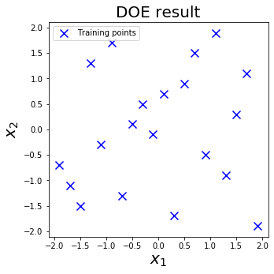

```python
# 시각화 (3D 문제 이상 부터는 불가능)
fig = plt.figure(figsize=(5, 5))
plt.scatter(xt[:,0],xt[:,1],marker = 'x',c='b',s=100,label='Training points')
plt.title('DOE result',fontsize=20)
plt.xlabel('$x_1$',fontsize=20)
plt.ylabel('$x_2$',fontsize=20)
plt.legend()
plt.show()
```

## **Step 3: 데이터 생성 (시뮬레이션 or 실험)**

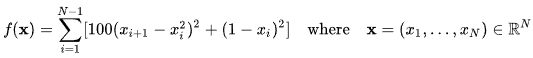

```python
# 아웃풋 데이터 생성 (실제 시뮬레이션 혹은 실험 수행)
yt = fun(xt) # 실제 아웃풋 데이터 생성

print("Output data",yt) # 아웃풋 데이터
```

```
Output data [[3.20900e+02]
 [6.70900e+02]
 [1.59930e+03]
 [4.25000e+01]
 [3.80500e+02]
 [8.28200e+01]
 [3.20900e+02]
 [1.02100e+02]
 [2.05000e+01]
 [3.23300e+02]
 [1.85000e+01]
 [2.42000e+00]
 [4.84200e+01]
 [1.71620e+02]
 [4.50000e+00]
 [1.41250e+03]
 [3.03682e+03]
 [2.32420e+02]
 [1.86602e+03]
 [4.76200e+01]]
```

## **Step 4: 대리 모델 구성 (Kriging)**

```python
# 대리모델링 (Main process)
initial_theta = [1e-2]*ndim # 초기 하이퍼파라미터 설정
sm = KRG(theta0 = initial_theta,print_prediction = False)
sm.set_training_values(xt,yt[:,0]) # 하이퍼파라미터 최적화
sm.train() # 하이퍼파라미터 최적화


# 하이퍼파라미터 변화
print("initial theta values",  initial_theta)
print("optimal theta values",  sm.optimal_theta)
```

```
___________________________________________________________________________

                                  Kriging
___________________________________________________________________________

 Problem size

      # training points.        : 20

___________________________________________________________________________

 Training

   Training ...
   Training - done. Time (sec):  0.1277947
initial theta values [0.01, 0.01]
optimal theta values [0.02650913 0.00013219]
```

## **Step 5: 모델 검증**

```python
# 모델 검증용 데이터 생성
ntest = 200
sampling = LHS(xlimits=fun.xlimits, criterion='ese', random_state=1)
xtest = sampling(ntest)
ytest = fun(xtest)
```

```
Kriging,  err: 0.0005665998329528192
```

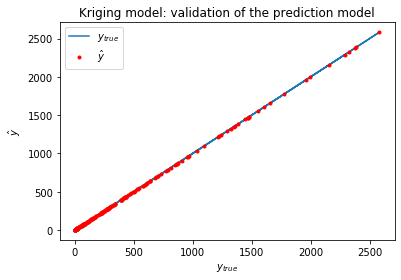

```python
# Prediction of the validation points
y_pred = sm.predict_values(xtest) # 최적화된 하이퍼파라미터가 적용된 크리깅 평균값 예측 모델
print('Kriging,  err: '+ str(compute_rms_error(sm,xtest,ytest)))

if plot_status:
    # Plot the function, the prediction and the 95% confidence interval based on
    # the MSE
    fig = plt.figure()
    plt.plot(ytest, ytest, '-', label='$y_{true}$')
    plt.plot(ytest, y_pred, 'r.', label='$\hat{y}$')

    plt.xlabel('$y_{true}$')
    plt.ylabel('$\hat{y}$')

    plt.legend(loc='upper left')
    plt.title('Kriging model: validation of the prediction model')

if plot_status:
    plt.show()
```

```python
from sklearn.metrics import mean_squared_error, r2_score

# The root mean squared error
print("Root mean squared error(RMSE): %.5f"
      % mean_squared_error(ytest, y_pred)**0.5)
```

```
Root mean squared error(RMSE): 0.40181
```

```python
# Plot the surrogate model in 3D
x = np.linspace(-2, 2, 50)
resSM = []
varSM = []
for x0 in x:
    for x1 in x:
        resSM.append(sm.predict_values(np.array([[x0,x1]])))
        varSM.append(sm.predict_variances(np.array([[x0,x1]])))
```

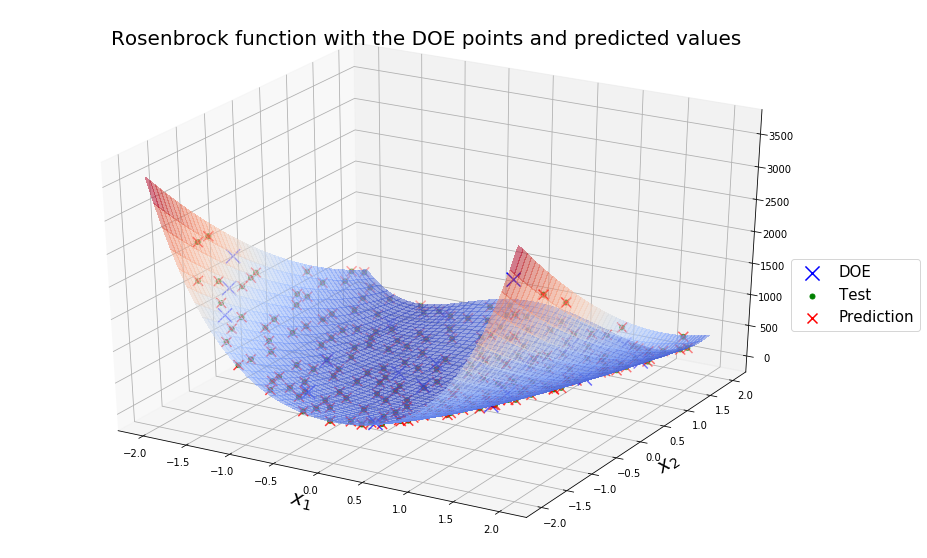

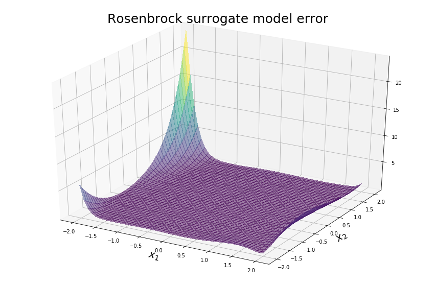

```python
# 결과 시각화
resSM = np.array(resSM)
resSM = resSM.reshape((50,50)).T
varSM = np.array(varSM)
varSM = varSM.reshape((50,50)).T
X,Y = np.meshgrid(x,x)

fig = plt.figure(figsize=(15, 10))
ax = fig.gca(projection='3d')
ax.scatter(xt[:,0], xt[:,1], yt, zdir='z', marker='x', c='b', s=200, label='DOE')
surf = ax.plot_surface(X, Y, resSM, cmap=cm.coolwarm,
                       linewidth=0, antialiased=False,alpha=0.5)
ax.scatter(xtest[:,0], xtest[:,1], ytest, zdir='z', marker='.', c='g', s=100, label='Test')
ax.scatter(xtest[:,0], xtest[:,1], y_pred, zdir='z', marker = 'x', c='r', s=100, label='Prediction')
plt.legend(fontsize=15,bbox_to_anchor=(1.1, 0.55))
plt.xlabel('$x_1$',fontsize=20)
plt.ylabel('$x_2$',fontsize=20)
plt.title('Rosenbrock function with the DOE points and predicted values',fontsize=20)

plt.show()

# Plot of the variance
fig = plt.figure(figsize=(15, 10))
ax = fig.gca(projection='3d')
surf = ax.plot_surface(X, Y, varSM, cmap=cm.viridis,
                       linewidth=0, antialiased=False, alpha=0.5)

plt.title('Rosenbrock surrogate model error',fontsize=25)
plt.xlabel('$x_1$',fontsize=20)
plt.ylabel('$x_2$',fontsize=20)
plt.show()
```

```python
# 예측값 및 불확실 정보 (테스트)
x_want = np.array([[1.2, 1.2]]) # 예측 포인트
y_want = sm.predict_values(x_want) # 예측값
s2_want = np.sqrt(sm.predict_variances(x_want)) # 불확실 정보
y_real = fun(x_want) # 실제값

print("예측값",y_want) # 예측값
print("불확실 정보",s2_want) # 불확실 정보
print("실제값",y_real) # 실제값
```

```
예측값 [[5.7444574]]
불확실 정보 [[0.23150012]]
실제값 [[5.8]]
```

### ※ **응용 문제**

- 설계 변수 개수: 4개
- 설계 공간: -3<x<sub>1</sub><3, -4<x<sub>2</sub><4, -10<x<sub>3</sub><1, -3<x<sub>4</sub><5
- 예제 함수: Rosenbrock function
- 데이터 개수: 40개
- 초기 하이퍼파라미터 설정: [10<sup>-1</sup>, 10<sup>-1</sup>, 10<sup>-1</sup>, 10<sup>-1</sup>]
- Kriging으로 대리모델링을 수행

```python
ndim = 2 # 설계 변수 개수 (차원)
ndoe = 20 # 초기 데이터 개수

fun = Rosenbrock(ndim = ndim) # Black-box 모델 정의 (e.g., 함수, 시뮬레이션 모델)

# 실험계획법 수행
# 디자인 영역에서 다른 샘플과 겹치지 않으면서 (orthogonality) 고르게 (space-filling) 데이터를 확보
sampling = LHS(xlimits = fun.xlimits, criterion = 'ese', random_state = 1) # 라틴 하이퍼 큐브 샘플링
xt = sampling(ndoe)

# 아웃풋 데이터 생성 (실제 시뮬레이션 혹은 실험 수행)
yt = fun(xt)

# 대리모델링 (Main process)
initial_theta = [1e-2]*ndim # 초기 하이퍼파라미터 설정
sm = KRG(theta0 = initial_theta,print_prediction = False)
sm.set_training_values(xt,yt[:,0]) # 하이퍼파라미터 최적화
sm.train() # 하이퍼파라미터 최적화


# 하이퍼파라미터 변화
print("initial theta values",  initial_theta)
print("optimal theta values",  sm.optimal_theta)

# 예측값 및 불확실 정보 (테스트)
x_want = np.array([[1.2, 1.2]]) # 예측 포인트
y_want = sm.predict_values(x_want) # 예측값
s2_want = np.sqrt(sm.predict_variances(x_want)) # 불확실 정보
y_real = fun(x_want) # 실제값
```

```
___________________________________________________________________________

                                  Kriging
___________________________________________________________________________

 Problem size

      # training points.        : 20

___________________________________________________________________________

 Training

   Training ...
   Training - done. Time (sec):  0.1445253
initial theta values [0.01, 0.01]
optimal theta values [0.02408469 0.00010993]
```

```python
print("예측값",y_want) # 예측값
print("불확실 정보",s2_want) # 불확실 정보
print("실제값",y_real) # 실제값
```

```
예측값 [[5.74179056]]
불확실 정보 [[0.17717948]]
실제값 [[5.8]]
```

### ※ **정답 코드**

```python
ndim = 4 # 설계 변수 개수 (차원)
ndoe = 40 # 초기 데이터 개수

fun = Rosenbrock(ndim=ndim) # Black-box 모델 정의 (e.g., 함수, 시뮬레이션 모델)

# 실험계획법 수행
# 디자인 영역에서 다른 샘플과 겹치지 않으면서 (orthogonality) 고르게 (space-filling) 데이터를 확보
design_xlimits = np.array([[-3,3],[-4,4],[-10,1],[-3,5]])
sampling = LHS(xlimits = design_xlimits, criterion = 'ese', random_state = 1) # 라틴 하이퍼 큐브 샘플링
xt = sampling(ndoe)

print("설계 영역",design_xlimits)
print("초기 실험 포인트",xt)

# 아웃풋 데이터 생성 (실제 시뮬레이션 혹은 실험 수행)
yt = fun(xt)

# 대리모델링 (Main process)
initial_theta = [1e-1]*ndim # 초기 하이퍼파라미터 설정
sm = KRG(theta0=initial_theta,print_prediction = False)
sm.set_training_values(xt,yt[:,0]) # 하이퍼파라미터 최적화
sm.train() # 하이퍼파라미터 최적화


# 하이퍼파라미터 변화
print("initial theta values",  initial_theta)
print("optimal theta values",  sm.optimal_theta)

# 예측값 및 불확실 정보 (테스트)
x_want = np.array([[1.2, 1.2, 1.2, 1.2]]) # 예측 포인트
y_want = sm.predict_values(x_want) # 예측값
s2_want = np.sqrt(sm.predict_variances(x_want)) # 불확실 정보
y_real = fun(x_want) # 실제값
```

```
설계 영역 [[ -3   3]
 [ -4   4]
 [-10   1]
 [ -3   5]]
초기 실험 포인트 [[-1.1568337   2.87757213 -4.94063887 -1.86153548]
 [ 0.39951622  1.32467202 -0.03792993  4.96936576]
 [ 1.50298202  2.0052422  -1.82933069 -2.93953349]
 [ 0.73550693  3.64065865 -3.39921066  3.59391915]
 [-1.92452544  1.73936363 -6.69467409  3.94942433]
 [ 0.19048918  3.22149883 -8.86139359  2.75109261]
 [ 2.03415453 -0.9171888  -7.51997072 -1.79218904]
 [-1.3345161   3.91627179 -1.32297396  0.08283585]
 [-1.54702486 -0.23852174 -9.16746841 -2.4629561 ]
 [-0.27910855 -2.80634768 -7.60973379 -0.74127717]
 [ 2.33343604  1.59946457 -9.99996855  0.42749494]
 [ 1.818626   -1.17065429 -0.41252599 -1.51577847]
 [-2.12988831 -3.78153228 -5.41745647  2.07145395]
 [-0.81388236 -2.03307487 -8.04795462  4.3425978 ]
 [-1.35167084 -3.8559351  -1.74221572  4.02426869]
 [-0.01087371 -0.48268899 -4.29349083 -2.73088785]
 [-2.64048488 -2.29336694 -5.68403996 -1.04997114]
 [ 1.33988932 -2.62107867  0.9917555   1.58989785]
 [ 2.78521507  3.02729105 -5.98794098  3.04924221]
 [-1.96854163 -0.69282072 -2.88136592  4.59345527]
 [ 0.79899674 -3.08826203 -9.67377844  1.92342898]
 [-1.65631657 -1.85036687  0.51938958  1.6474054 ]
 [-2.82798662 -1.34689067 -8.32661284  2.38588745]
 [ 1.46308143  3.4025112  -4.56852667 -0.38932749]
 [-1.01825578  1.98460491 -1.0389162   2.82485419]
 [ 0.51748682  2.30776621 -8.53880835 -2.1603797 ]
 [-2.33740428 -0.13044683 -3.91844486  1.39296801]
 [ 2.22106578 -3.49223665 -4.10727492 -0.46423289]
 [-0.73464984  0.37917724 -9.33472151  1.06977967]
 [ 1.03628027  0.71567792 -6.28981738  4.74876517]
 [-2.51933216 -1.71042129 -0.70482602 -2.2659065 ]
 [-0.59250698  0.9147359  -0.35852264 -1.33689687]
 [ 1.77900419  2.60372946  0.19479293  0.63307084]
 [ 1.15363454 -2.4243715  -2.84564916  3.36840618]
 [-2.9374467   2.45583674 -6.72513624  0.30297782]
 [-0.30831079 -3.22437651 -2.52760636 -0.84214413]
 [ 0.13249591  1.10541162 -5.07656447  0.9451996 ]
 [ 2.63395755  0.52433914 -3.56276238 -0.06004833]
 [ 2.87931442  0.12473444 -2.28184995  3.64659485]
 [ 2.40668278 -1.57399429 -7.1728779   2.42742715]]
___________________________________________________________________________

                                  Kriging
___________________________________________________________________________

 Problem size

      # training points.        : 40

___________________________________________________________________________

 Training

   Training ...
   Training - done. Time (sec):  0.3426747
initial theta values [0.1, 0.1, 0.1, 0.1]
optimal theta values [0.00793898 0.0057096  0.29862073 0.00049371]
```

```python
print("예측값",y_want) # 예측값
print("불확실 정보",s2_want) # 불확실 정보
print("실제값",y_real) # 실제값
```

```
예측값 [[-14329.57785701]]
불확실 정보 [[9455.57206956]]
실제값 [[17.4]]
```